# Predictive analysis-exercise

Nivedita M Nair

October 11, 2020

## Overview

The aim of this project is to predict the manner in which participants perform an exercise . The data is taken using devices such as Jawbone Up, Nike FuelBand, and Fitbit accelerometers placed on the belt, forearm, arm, and dumbell.

## 1. Data Preprocessing

Load the training and testing set from the online sources and then split the training set further into training and test sets.

```r
library(caret)
```

```r
trainURL <- "http://d396qusza40orc.cloudfront.net/predmachlearn/pml-training.csv"
testURL <- "http://d396qusza40orc.cloudfront.net/predmachlearn/pml-testing.csv"
training <- read.csv(url(trainURL))
testing <- read.csv(url(testURL)) #reading data

label <- createDataPartition(training$classe, p = 0.7, list = FALSE) #slicing
train <- training[label, ]
test <- training[-label, ]
```

160 variables are present in the dataset, variables containing NA terms and zero variance need to be excluded from the dataset.

```r
NZV <- nearZeroVar(train) #zero variance
train <- train[ ,-NZV]
test <- test[ ,-NZV]
label <- apply(train, 2, function(x) mean(is.na(x))) > 0.95
train <- train[, -which(label, label == FALSE)]
test <- test[, -which(label, label == FALSE)]
train <- train[ , -(1:5)]
test <- test[ , -c(1:5)]
```

As a result of the preprocessing steps, we were able to reduce 160 variables to 54.

## Exploratory Analysis

Dependence of the variables on each other is found using a correlation plot after dataset is cleaned.

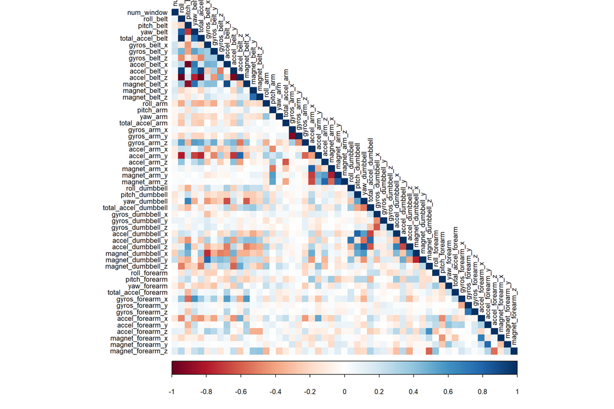

```r
library(corrplot)
corrMat <- cor(train[,-54])
corrplot(corrMat, method = "color", type = "lower", tl.cex = 0.8, tl.col = rgb(0,0,0))
```

In the plot above, darker gradient correspond to having high correlation.

## Prediction Model Selection

### Decision Tree

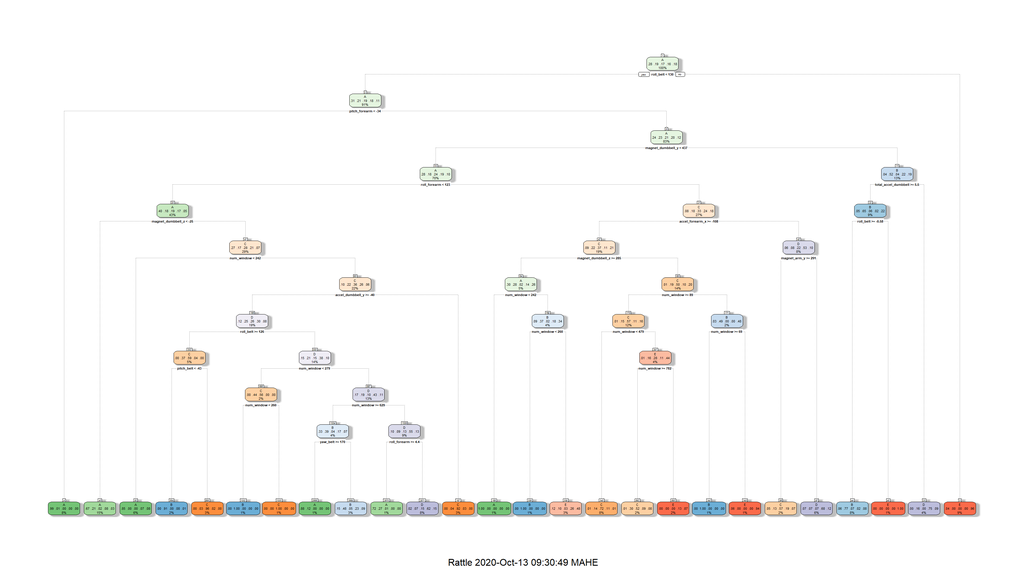

```r
library(rpart)
library(rpart.plot)
library(rattle)
set.seed(13908)
modelDT <- rpart(classe ~ ., data = train, method = "class")
fancyRpartPlot(modelDT)
```

```r
predictDT <- predict(modelDT, test, type = "class")
confMatDT <- confusionMatrix(predictDT, test$classe)#for comparison package e1071
confMatDT
```

```
## Confusion Matrix and Statistics
##
##           Reference
## Prediction    A    B    C    D    E
##          A 1530  205   22   82   65
##          B   60  679   47   76   67
##          C   15  166  877  106   19
##          D   19   81   74  636  122
##          E   50    8    6   64  809
##
## Overall Statistics
##
##                Accuracy : 0.7699
##                  95% CI : (0.759, 0.7806)
##     No Information Rate : 0.2845
##     P-Value [Acc > NIR] : < 2.2e-16
##
##                   Kappa : 0.7077
##
##  Mcnemar's Test P-Value : < 2.2e-16
##
## Statistics by Class:
##
##                      Class: A Class: B Class: C Class: D Class: E
## Sensitivity            0.9140   0.5961   0.8548   0.6598   0.7477
## Specificity            0.9112   0.9473   0.9370   0.9398   0.9733
## Pos Pred Value         0.8036   0.7309   0.7413   0.6824   0.8634
## Neg Pred Value         0.9638   0.9072   0.9683   0.9338   0.9448
## Prevalence             0.2845   0.1935   0.1743   0.1638   0.1839
## Detection Rate         0.2600   0.1154   0.1490   0.1081   0.1375
## Detection Prevalence   0.3235   0.1579   0.2010   0.1584   0.1592
## Balanced Accuracy      0.9126   0.7717   0.8959   0.7998   0.8605
```

### Random Forest

```r
library(caret)
#set.seed(13908)
control <- trainControl(method = "cv", number = 3, verboseIter=FALSE)
modelRF <- train(classe ~ ., data = train, method = "rf", trControl = control)
predictRF <- predict(modelRF, test)
confMatRF <- confusionMatrix(predictRF, test$classe)#for comparison
confMatRF
```

```
## Confusion Matrix and Statistics
##
##           Reference
## Prediction    A    B    C    D    E
##          A 1673    1    0    0    0
##          B    0 1137    1    0    0
##          C    0    1 1025    5    0
##          D    0    0    0  958    2
##          E    1    0    0    1 1080
##
## Overall Statistics
##
##                Accuracy : 0.998
##                  95% CI : (0.9964, 0.9989)
##     No Information Rate : 0.2845
##     P-Value [Acc > NIR] : < 2.2e-16
##
##                   Kappa : 0.9974
##
##  Mcnemar's Test P-Value : NA
##
## Statistics by Class:
##
##                      Class: A Class: B Class: C Class: D Class: E
## Sensitivity            0.9994   0.9982   0.9990   0.9938   0.9982
## Specificity            0.9998   0.9998   0.9988   0.9996   0.9996
## Pos Pred Value         0.9994   0.9991   0.9942   0.9979   0.9982
## Neg Pred Value         0.9998   0.9996   0.9998   0.9988   0.9996
## Prevalence             0.2845   0.1935   0.1743   0.1638   0.1839
## Detection Rate         0.2843   0.1932   0.1742   0.1628   0.1835
## Detection Prevalence   0.2845   0.1934   0.1752   0.1631   0.1839
## Balanced Accuracy      0.9996   0.9990   0.9989   0.9967   0.9989
```

## Predicting Test Set Output

```r
predictRF <- predict(modelRF, testing)
predictRF
```

```
##  [1] B A B A A E D B A A B C B A E E A B B B
## Levels: A B C D E
```